# Assignment 1 - ESM 244

Claire Madden

1/26/2020

## Task 1.

snowshoe hare data : Kielland K., F. S. Chapin, R. W. Ruess. 2017. Snowshoe hare physical data in Bonanza Creek Experimental Forest: 1999-Present. Environmental Data Initiative. https://doi.org/10.6073/pasta/03dce4856d79b91557d8e6ce2cbcdc14.

Prepare a single polished HTML (knitted from .Rmd), planning that this might be a post/project you’d include on your personal blogdown site, that includes at least:

A useful descriptive introductory summary (3 - 4 sentences) of what’s contained in the project Image(s), with captions and necessary citation(s), of showshoe hares and/or a map of the study area All of your organized and well-annotated code (with warnings/messages hidden) used to create at least:

One finalized graph about the Bonanza Creek snowshoe hare population (you pick which variables, how you want to wrangle it beforehand, and which type of visual to create - but make sure it is beautifully finalized)

One finalized HTML table (probably created using kable & kableExtra) containing summary statistics about the snowshoe hares (again, you pick which variables, and how you want to group/summarize them)

Make sure that both your figure and table appear in your final knitted document, each with a useful caption. Include text associated with each to help the audience understand and interpret the results.

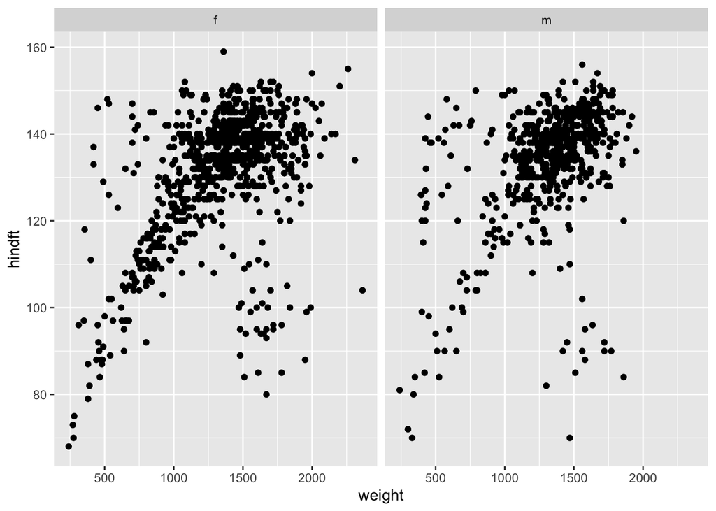

```r
library(tidyverse)
library(kableExtra)
library(janitor)
library(lubridate)
library(tidyr)
library(ggfortify)
library(RColorBrewer)

hares<- read_csv("showshoe_lter.csv")

hares_mf <- hares %>%
  mutate(sex = str_to_lower(sex)) %>% # change all entries in sex column to lower case
  filter(sex == "m" | sex == "f") %>% # remove all observations with NA or ? in sex
  mutate(date = mdy(date)) %>% # change date format
  mutate(full_date = date) %>% # retain date column
  separate(date, into = c("year", "month", "day")) %>% #create new columns with parsed date info
  mutate(month = as.numeric(month)) %>%
  mutate(season = ifelse(month %in% c(1:4, 11, 12), "winter", "summer")) %>% # organize months into "summer" and "winter"
  mutate(year = as.numeric(year))

# seems like there are a lot more observations in the summer than in the winter so maybe not an interesting thing to use for visualization


# explore graph
ggplot(data = hares_mf, aes(x = weight, y = hindft))+
  geom_point()+
  facet_wrap(~sex)
```

```r
# this is not that interesting to me
```

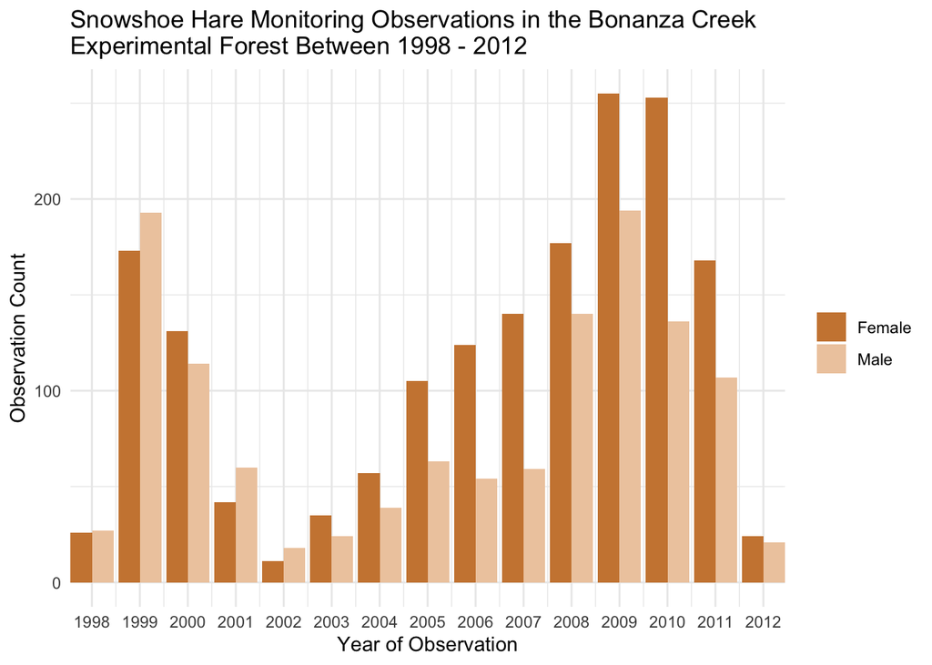

```r
# try something else that may be more interesting

hares_hist <- ggplot(data = hares_mf, aes(x = year))+
  geom_bar(aes(fill = sex), position = "dodge")+
  scale_fill_manual(values = c("peru", "peachpuff2"), labels = c("Female", "Male"))+
  scale_x_continuous(expand = c(0,0),
                     breaks = seq(1998, 2012, 1))+
  theme_minimal()+
  labs(x = "Year of Observation",
       y = "Observation Count",
       title = "Snowshoe Hare Monitoring Observations in the Bonanza Creek \nExperimental Forest Between 1998 - 2012")+
  theme(legend.title = element_blank())


hares_hist
```

```r
# make a summary table for females
hare_summary_f <- hares_mf %>%
  filter(sex == "f") %>%
  drop_na(weight, hindft) %>% # take out an values to be able to calculate mean
  group_by(year) %>% # organize by year and sex
  summarize(
    count = length(sex), # number of observations
    avg_weight = round(mean(weight), digits = 0))# mean weight

# make a summary table for males
hare_summary_m <- hares_mf %>%
  filter(sex == "m") %>%
  drop_na(weight, hindft) %>% # take out an values to be able to calculate mean
  group_by(year) %>% # organize by year and sex
  summarize(
    count = length(sex), # number of observations
    avg_weight = round(mean(weight), digits = 0)) # mean weight


# combine the two tables!
hare_summary <- merge(hare_summary_f, hare_summary_m, by = "year")

# format into a single pretty table
hare_table <- kable(hare_summary, align = "c", col.names = c("Year", "Count", "Average Weight", "Count", "Average Weight"), caption = "Table 1. Sumamry Statistics for Snowshoe Hare Monitoring at Bonanza Creek Experimental Forest Between 1998 - 2012") %>%
  add_header_above(c(" " = 1, "Female" = 2, "Male" = 2)) %>%
  kable_styling(bootstrap_options = c("striped"), full_width = FALSE)

hare_table
```

Table 1. Sumamry Statistics for Snowshoe Hare Monitoring at Bonanza Creek Experimental Forest Between 1998 - 2012

| Year | Female Count | Female Average Weight | Male Count | Male Average Weight |
| --- | --- | --- | --- | --- |
| 1998 | 10 | 1746 | 5 | 1678 |
| 1999 | 113 | 1335 | 136 | 1241 |
| 2000 | 78 | 1517 | 47 | 1302 |
| 2001 | 25 | 1482 | 27 | 1420 |
| 2002 | 10 | 1014 | 17 | 1301 |
| 2003 | 33 | 1206 | 23 | 1223 |
| 2004 | 45 | 1536 | 29 | 1372 |
| 2005 | 47 | 1162 | 36 | 1297 |
| 2006 | 29 | 1283 | 15 | 1443 |
| 2007 | 57 | 1412 | 25 | 1190 |
| 2008 | 87 | 1331 | 76 | 1360 |
| 2009 | 117 | 1281 | 100 | 1325 |
| 2010 | 96 | 1299 | 43 | 1350 |
| 2011 | 85 | 1339 | 43 | 1400 |
| 2012 | 24 | 1291 | 21 | 1331 |

## Task 2.

For this task, I’ll provide a couple of datasets that you *can* use for PCA exploration, but you are also welcome to find/choose a different dataset to use. You only need to use one dataset to practice running PCA, creating a biplot, and interpreting the results. Whichever dataset you choose, create a finalized HTML (knitted from .Rmd) that can be included as a project on your blogdown site including:

A useful descriptive introductory summary (3 - 4 sentences) that helps the audience understand the data (include a citation as necessary) and what you’ll be exploring All of your organized and well-annotated code (with warnings/messages hidden) used to wrangle then run PCA, then create a finalized PCA biplot that appears (with a caption) in your knitted HTML A summary (bulletpoints are fine) pointing out some major takeaways from your PCA that can be gleaned from the biplot You are also welcome to include a photo in the HTML to add some visual interest (not required for Task 2).

```r
# explore data

world_env <- read_csv("world_env_vars.csv") %>%
  clean_names(case = "upper_camel")

summary(world_env) # check out the dataset
```

```
##    Country          AccessibilityToCities   Elevation          Aspect
##  Length:243         Min.   :    0.969     Min.   :   0.0   Min.   :  0.0
##  Class :character   1st Qu.:   73.534     1st Qu.: 110.6   1st Qu.:159.1
##  Mode  :character   Median :  214.508     Median : 301.4   Median :174.6
##                     Mean   :  911.394     Mean   : 475.7   Mean   :169.1
##                     3rd Qu.:  625.937     3rd Qu.: 598.9   3rd Qu.:186.7
##                     Max.   :15531.333     Max.   :5428.8   Max.   :310.9
##                     NA's   :5             NA's   :6        NA's   :6
##      Slope         CroplandCover     TreeCanopyCover  Isothermality
##  Min.   :0.00000   Min.   : 0.0000   Min.   : 0.000   Min.   :15.40
##  1st Qu.:0.04247   1st Qu.: 0.3798   1st Qu.: 6.392   1st Qu.:33.82
##  Median :0.39781   Median : 7.2246   Median :18.269   Median :53.77
##  Mean   :0.69560   Mean   :17.1011   Mean   :22.055   Mean   :52.94
##  3rd Qu.:1.08622   3rd Qu.:27.6608   3rd Qu.:35.973   3rd Qu.:68.50
##  Max.   :3.69839   Max.   :77.5280   Max.   :71.896   Max.   :93.98
##  NA's   :6                           NA's   :11       NA's   :6
##  RainColdestQuart    RainDriestMonth   RainDriestQuart  RainMeanAnnual
##  Min.   :   0.0312   Min.   :  0.000   Min.   :  0.00   Min.   :  14.16
##  1st Qu.:  80.9375   1st Qu.:  5.149   1st Qu.: 30.04   1st Qu.: 587.12
##  Median : 179.9202   Median : 29.308   Median :104.80   Median :1043.14
##  Mean   : 238.6579   Mean   : 40.628   Mean   :141.23   Mean   :1231.09
##  3rd Qu.: 312.4570   3rd Qu.: 58.934   3rd Qu.:204.14   3rd Qu.:1785.77
##  Max.   :1271.9904   Max.   :238.593   Max.   :843.66   Max.   :4547.62
##  NA's   :6           NA's   :5         NA's   :5        NA's   :5
##  RainSeasonailty  RainWarmestQuart RainWettestMonth  RainWettestQuart
##  Min.   : 10.68   Min.   :   0.0   Min.   :  3.757   Min.   :   8.929
##  1st Qu.: 30.95   1st Qu.: 146.9   1st Qu.: 83.786   1st Qu.: 228.930
##  Median : 50.71   Median : 254.5   Median :148.664   Median : 417.478
##  Mean   : 56.52   Mean   : 334.3   Mean   :189.669   Mean   : 505.238
##  3rd Qu.: 80.28   3rd Qu.: 482.0   3rd Qu.:288.801   3rd Qu.: 762.228
##  Max.   :152.52   Max.   :1385.1   Max.   :592.526   Max.   :1552.554
##  NA's   :5        NA's   :6        NA's   :5         NA's   :5
##  TempAnnualRange  TempColdestQuart  TempDiurnalRange TempDriestQuart
##  Min.   : 5.467   Min.   :-28.507   Min.   : 2.879   Min.   :-19.85
##  1st Qu.:11.773   1st Qu.:  2.916   1st Qu.: 7.181   1st Qu.: 11.22
##  Median :19.841   Median : 18.558   Median : 9.351   Median : 22.32
##  Mean   :20.932   Mean   : 13.384   Mean   : 9.615   Mean   : 17.50
##  3rd Qu.:27.938   3rd Qu.: 23.576   3rd Qu.:11.722   3rd Qu.: 25.23
##  Max.   :50.631   Max.   : 28.076   Max.   :16.269   Max.   : 35.22
##  NA's   :6        NA's   :6         NA's   :6        NA's   :6
##  TempMaxWarmestMonth TempMeanAnnual   TempMinColdestMonth TempSeasonality
##  Min.   : 0.9144     Min.   :-17.21   Min.   :-32.5573    Min.   :  1.169
##  1st Qu.:26.1472     1st Qu.: 10.75   1st Qu.: -0.7255    1st Qu.: 11.086
##  Median :30.4065     Median : 22.25   Median : 11.6422    Median : 29.804
##  Mean   :29.1116     Mean   : 18.47   Mean   :  8.1800    Mean   : 38.666
##  3rd Qu.:32.6014     3rd Qu.: 25.52   3rd Qu.: 18.4214    3rd Qu.: 62.669
##  Max.   :43.8417     Max.   : 28.26   Max.   : 25.3397    Max.   :145.221
##  NA's   :6           NA's   :6        NA's   :6           NA's   :6
##  TempWarmestQuart TempWettestQuart      Wind          Cloudiness
##  Min.   :-3.307   Min.   :-12.29   Min.   : 1.203   Min.   : 50.36
##  1st Qu.:19.456   1st Qu.: 13.14   1st Qu.: 2.196   1st Qu.:170.54
##  Median :25.226   Median : 23.05   Median : 2.777   Median :205.81
##  Mean   :23.227   Mean   : 19.45   Mean   : 3.071   Mean   :200.50
##  3rd Qu.:27.373   3rd Qu.: 25.60   3rd Qu.: 3.707   3rd Qu.:237.90
##  Max.   :35.217   Max.   : 31.85   Max.   :11.188   Max.   :322.19
##  NA's   :6        NA's   :6        NA's   :55       NA's   :8
```

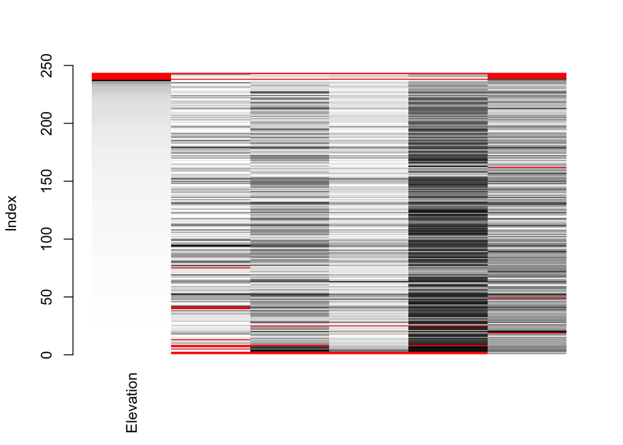

```
##
## Click in a column to sort by the corresponding variable.
## To regain use of the VIM GUI and the R console, click outside the plot region.
```

```r
env_subset <- world_env %>%
  select(Elevation, TreeCanopyCover, Isothermality, RainMeanAnnual, TempMeanAnnual, Cloudiness) # select variables of interest for principal components analysis


VIM::matrixplot(env_subset, sortby = "Elevation")
```

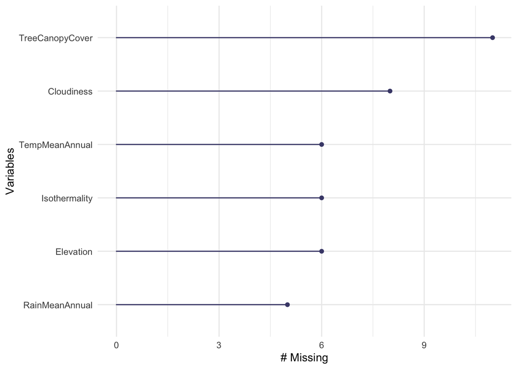

```r
# can't see variable names so not that helpful for exploration

naniar::gg_miss_var(env_subset)
```

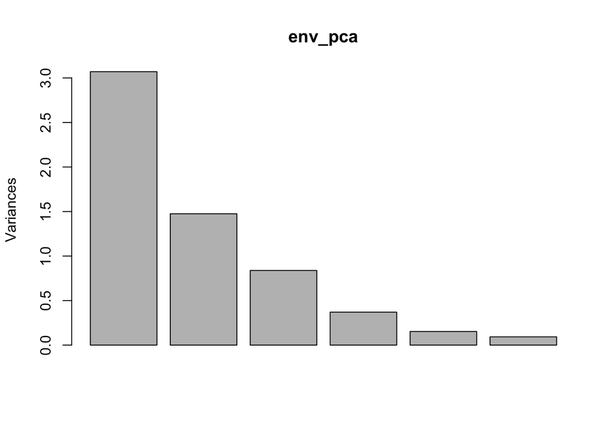

```r
# only a few NAs for each variable, will remove them

env_nona <- env_subset %>%
  drop_na() # remove NA values



env_pca <- prcomp(env_nona, scale = TRUE) # run PCA

plot(env_pca)
```

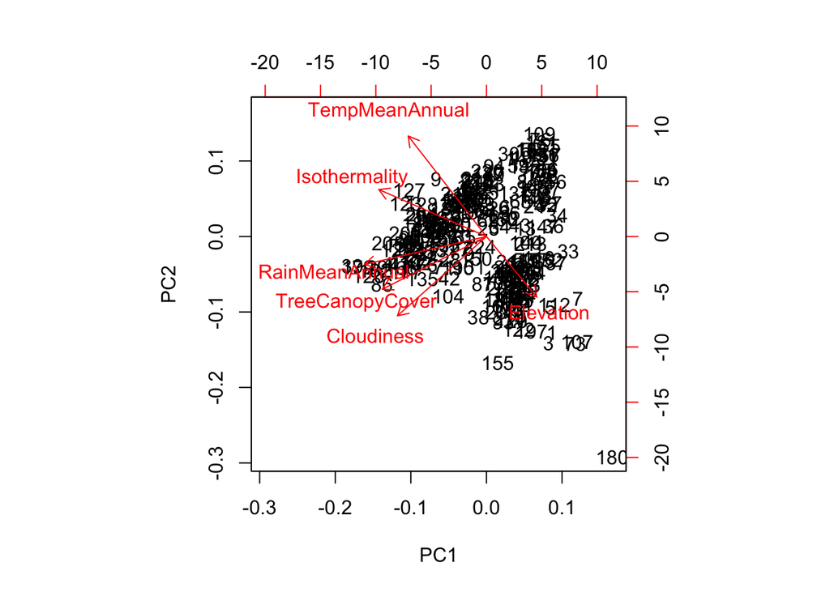

```r
biplot(env_pca) # lookin real UGLY!
```

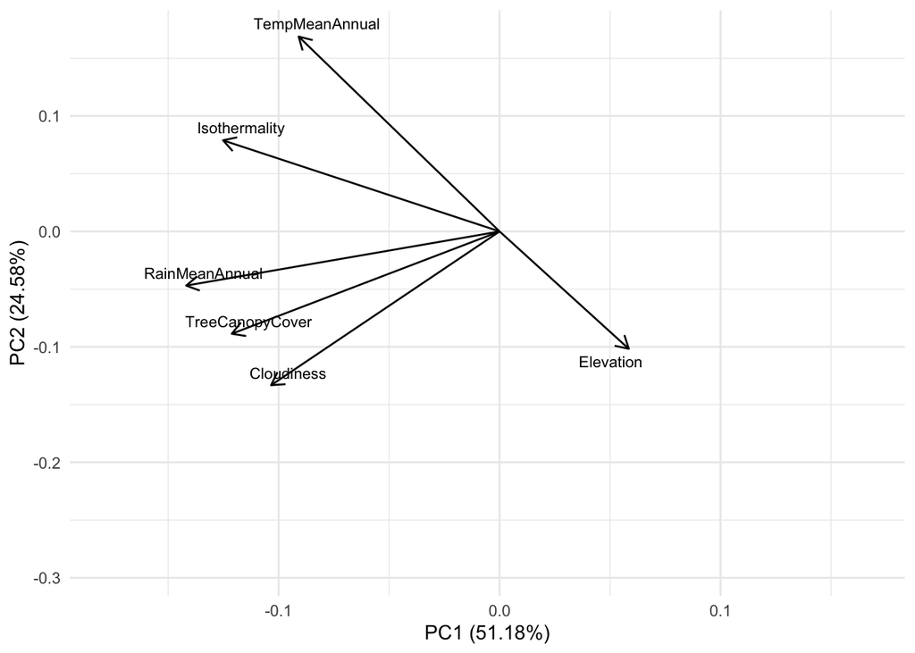

```r
# a prettier version...
my_pca_plot <- autoplot(env_pca,
                        colour = NA,
                        loadings.colour = "black",
                        loadings.label = TRUE,
                        loadings.label.size = 3,
                        loadings.label.colour = "black",
                        loadings.label.repel = TRUE)+
  theme_minimal()



my_pca_plot
```